# Untitled

Roman Olenev

2023-12-25

```r
dataset <- read.csv("C:/Users/roman/Downloads/possum.csv")
head(dataset)
```

```
##   case site Pop sex age hdlngth skullw totlngth taill footlgth earconch  eye
## 1    1    1 Vic   m   8    94.1   60.4     89.0  36.0     74.5     54.5 15.2
## 2    2    1 Vic   f   6    92.5   57.6     91.5  36.5     72.5     51.2 16.0
## 3    3    1 Vic   f   6    94.0   60.0     95.5  39.0     75.4     51.9 15.5
## 4    4    1 Vic   f   6    93.2   57.1     92.0  38.0     76.1     52.2 15.2
## 5    5    1 Vic   f   2    91.5   56.3     85.5  36.0     71.0     53.2 15.1
## 6    6    1 Vic   f   1    93.1   54.8     90.5  35.5     73.2     53.6 14.2
##   chest belly
## 1  28.0    36
## 2  28.5    33
## 3  30.0    34
## 4  28.0    34
## 5  28.5    33
## 6  30.0    32
```

```r
dataset <- dataset %>% select(-case)
```

Датасет состоит из девяти морфометрических измерений каждого из 104 горных опоссумов, пойманных в ловушку в семи местах от Южной Виктории до центрального Квинсленда. Задача состоит в классификации опоссумов по популяции.

site - место, в котором поймали опоссума

Pop - популяция: Vic - Victoria, other - New South Wales or Queensland

sex - пол

age - возраст

hdlngth - длина головы в мм

skullw - ширина черепа в мм

totlngth - полная длина в см

taill - длина хвоста

footlgth - длина лапы

earconch - длина ушной раковины

eye - длина правого глаза

chest - обхват груди в см

belly - обхват живота в см

Удаляем пропуски в данных.

```r
na_num <- sapply(dataset, function(y) sum(length(which(is.na(y)))))
na_num
```

```
##     site      Pop      sex      age  hdlngth   skullw totlngth    taill
##        0        0        0        2        0        0        0        0
## footlgth earconch      eye    chest    belly
##        1        0        0        0        0
```

```r
dataset1 <- drop_na(dataset)
sum(is.na(dataset1))
```

```
## [1] 0
```

pairplot, видна неоднородность.

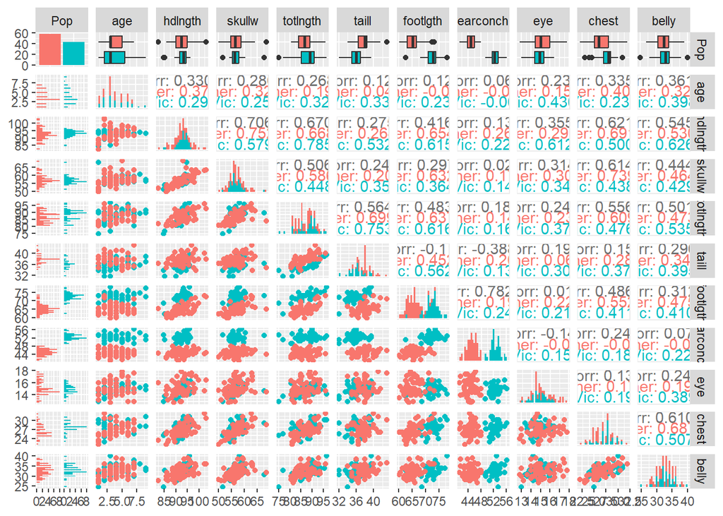

```r
dataset2 <- dataset1 %>% select(-c(sex, site))
ggpairs(dataset2, aes(color=Pop), diag=list(continuous="barDiag"))
```

PCA для визуализации.

```r
dataset_pca <- dataset2 %>% select(-Pop)
pcaclass <- PCA(dataset_pca)
```

[figure not shown]

[figure not shown]

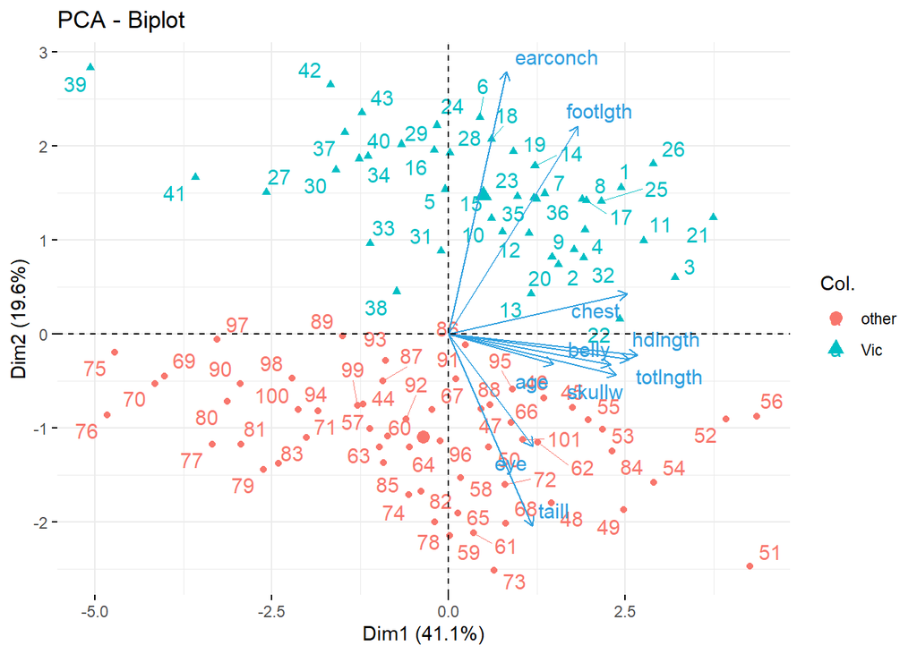

```r
fviz_pca_biplot(pcaclass, repel = TRUE,
                col.var = "#2E9FDF",
                col.ind = as.factor(dataset2$Pop),
                )
```

MANOVA. Смотрим на то, отличаются ли средние по признакам между разными группами. Критерии Roy и Wilks отвергают гипотезу о равенстве, средние отличаются.

```r
library("MASS")
full.manova <- manova(cbind(age,hdlngth,skullw,totlngth,taill,footlgth,earconch,eye,chest,belly) ~ Pop, data = dataset2)

summary(full.manova, 'Wilks')
```

```
##           Df    Wilks approx F num Df den Df    Pr(>F)
## Pop        1 0.072336   115.42     10     90 < 2.2e-16 ***
## Residuals 99
## ---
## Signif. codes:  0 '***' 0.001 '**' 0.01 '*' 0.05 '.' 0.1 ' ' 1
```

```r
summary(full.manova, 'Roy')
```

```
##           Df    Roy approx F num Df den Df    Pr(>F)
## Pop        1 12.824   115.42     10     90 < 2.2e-16 ***
## Residuals 99
## ---
## Signif. codes:  0 '***' 0.001 '**' 0.01 '*' 0.05 '.' 0.1 ' ' 1
```

```r
full.manova
```

```
## Call:
##    manova(cbind(age, hdlngth, skullw, totlngth, taill, footlgth,
##     earconch, eye, chest, belly) ~ Pop, data = dataset2)
##
## Terms:
##                       Pop Residuals
## age                2.3783  364.4138
## hdlngth            2.0878 1236.0470
## skullw             1.5054  961.1562
## totlngth          31.5682 1729.7467
## taill             89.9489  298.8035
## footlgth        1221.6598  726.2398
## earconch        1412.3998  236.2457
## eye                2.4457  109.6267
## chest             23.7809  384.5508
## belly              1.7319  742.3275
## Deg. of Freedom         1        99
##
## Residual standard errors: 1.91858 3.533458 3.11587 4.179975 1.737302 2.70846 1.544772 1.052303 1.970876 2.738295
## Estimated effects may be unbalanced
```

Классификация с помощью LDA по всем данным.

```r
full.lda <- lda(dataset2[,2:11], dataset2[,1]) #LDA
full.lda
```

```
## Call:
## lda(dataset2[, 2:11], dataset2[, 1])
##
## Prior probabilities of groups:
##     other       Vic
## 0.5742574 0.4257426
##
## Group means:
##            age  hdlngth   skullw totlngth    taill footlgth earconch      eye
## other 3.689655 92.60690 57.06552 86.78793 37.86207 65.40345 44.91379 15.18448
## Vic   4.000000 92.89767 56.81860 87.91860 35.95349 72.43721 52.47674 14.86977
##          chest    belly
## other 26.64655 32.52586
## Vic   27.62791 32.79070
##
## Coefficients of linear discriminants:
##                  LD1
## age       0.12450937
## hdlngth  -0.21142732
## skullw   -0.09770567
## totlngth  0.11706548
## taill    -0.47321520
## footlgth  0.29230265
## earconch  0.52678059
## eye       0.05979755
## chest     0.11929578
## belly    -0.01730144
```

Предсказания и ошибки классификации LDA (confusion matrix). Классифицировали без ошибок.

```r
full.ldap <- predict(full.lda, dataset2[,2:11]) #предсказываем
#таблица ошибок классификации
full.ldapc <- full.ldap$class
lda_full <- table(full.ldapc, dataset2[,1])
lda_full
```

```
##
## full.ldapc other Vic
##      other    58   0
##      Vic       0  43
```

```r
diag(prop.table(lda_full, 2)) #Столбцы - настоящие классы, строки - предсказанные классы.
```

```
## other   Vic
##     1     1
```

Так как данных мало, оценим качество предсказаний LDA с помощью кросс-валидации (confusion matrix). Ошибок тоже нет.

```r
#Кросс-валидация
cv.lda <- lda(dataset2[,2:11], dataset2[,1], CV = T)
cv.ldac <- cv.lda$class
lda_cv <- table(cv.ldac, dataset2[,1])
lda_cv
```

```
##
## cv.ldac other Vic
##   other    58   0
##   Vic       0  43
```

```r
diag(prop.table(lda_cv, 2))
```

```
## other   Vic
##     1     1
```

Классификация с помощью QDA по всем данным.

```r
#QDA
full.qda <- qda(dataset2[,2:11], dataset2[,1])
full.qda
```

```
## Call:
## qda(dataset2[, 2:11], dataset2[, 1])
##
## Prior probabilities of groups:
##     other       Vic
## 0.5742574 0.4257426
##
## Group means:
##            age  hdlngth   skullw totlngth    taill footlgth earconch      eye
## other 3.689655 92.60690 57.06552 86.78793 37.86207 65.40345 44.91379 15.18448
## Vic   4.000000 92.89767 56.81860 87.91860 35.95349 72.43721 52.47674 14.86977
##          chest    belly
## other 26.64655 32.52586
## Vic   27.62791 32.79070
```

Предсказания и ошибки классификации QDA (confusion matrix). Ошибок нет.

```r
full.qdap <- predict(full.qda, dataset2[,2:11])
full.qdapc <- full.qdap$class
qda_full <- table(full.qdapc, dataset2[,1])
qda_full
```

```
##
## full.qdapc other Vic
##      other    58   0
##      Vic       0  43
```

```r
diag(prop.table(qda_full, 2))
```

```
## other   Vic
##     1     1
```

Confusion matrix для QDA, кросс-валидация. Есть одна ошибка - неправильно классифицировали индивида с классом Vic.

```r
#Кросс-валидация
cv.qda <- qda(dataset2[,2:11], dataset2[,1], CV = T)
cv.qdac <- cv.qda$class
qda_cv <- table(cv.qdac, dataset2[,1])
qda_cv
```

```
##
## cv.qdac other Vic
##   other    58   1
##   Vic       0  42
```

```r
diag(prop.table(qda_cv, 2))
```

```
##     other       Vic
## 1.0000000 0.9767442
```

Это индивид под номером 17.

```r
which(cv.qdac!=dataset2[,1])
```

```
## [1] 17
```

Построим ROC-кривые. Для LDA.

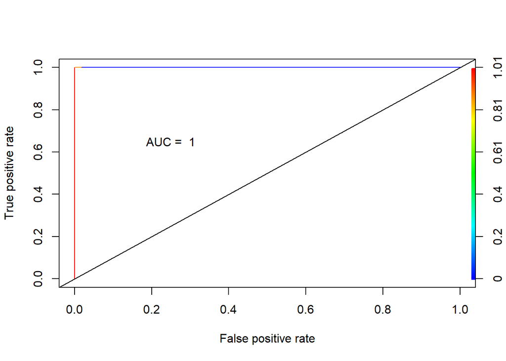

```r
two.cv.lda <- lda(dataset2[,2:11], dataset2[,1], CV = T)
predcv <- prediction(two.cv.lda$posterior[,2], dataset2[,1])
perfcv <- performance(predcv, "tpr", "fpr")
plot(perfcv, colorize = TRUE)
AUCcv <- performance(predcv, "auc")
abline(a = 0, b = 1)
text(x = .25, y = .65, paste("AUC = ", round(AUCcv@y.values[[1]],5)))
```

Для QDA.

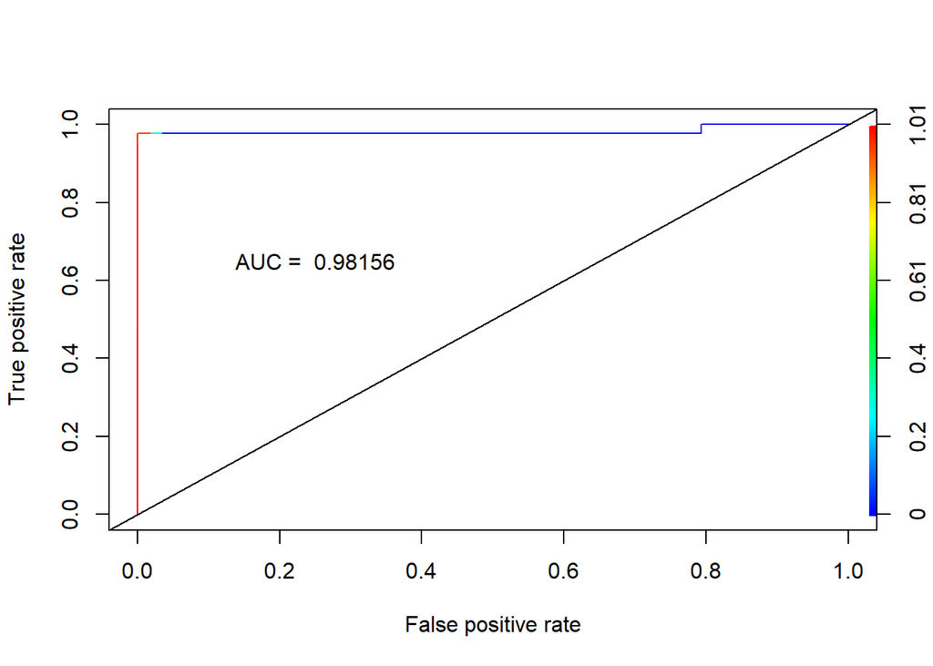

```r
predcv2 <- prediction(cv.qda$posterior[,2], dataset2[,1])
perfcv2 <- performance(predcv2, "tpr", "fpr")
plot(perfcv2, colorize = TRUE)
AUCcv2 <- performance(predcv2, "auc")
abline(a = 0, b = 1)
text(x = .25, y = .65, paste("AUC = ", round(AUCcv2@y.values[[1]],5)))
```

LDA в данном случае лучше, так как точнее при кросс-валидации.